# 431 Class 04

Thomas E. Love, Ph.D.

2026-09-03

## Today’s Agenda

Today, we’ll work with some data from the 15-item survey from Class 2.

- Ingesting data from a .csv file
- Data management and clean-up
- Dealing with missing data via “complete cases”
- Addressing a few exploratory comparisons
- Visualization, Modeling and Inference

One goal is to make sure you’re ready for Lab 1, due 2026-09-09.

## How did ingesting the data go?

The 2026 results ([pdf of survey is here](https://github.com/THOMASELOVE/431-classes-2026/blob/main/class02/class02-survey-431-2026.pdf)):

- I received 41 paper surveys.
- Two surveys had identical responses, so I dropped one.

In all, 14 of the 41 (**34.1%**) responses gave me no trouble in 2026. In 2014-2025, 36% of forms gave me no trouble.

Issues seen in 2026: interpreting handwriting, imprecise circles, cross-outs, not following directions on pulse rate, problems interpreting the handedness scale, difficult to identify units of measurement, listing multiple colors

## What have I done to set up today?

From 431-data, I have:

- `431-first-r-template.qmd`: our Quarto starting point
- `Love-431.R` script (for the `lovedist()` function)
- `class02_survey_2014_to_2026.csv`: main data file

Then I created an R Project directory for this work, which has the Quarto template in the main directory, and the .R and .csv files in a “c04/data” subdirectory.

## Next steps

1. Open RStudio
2. Start a new R Project in the Project Directory I created on the previous slide.
3. Open the Quarto template, then saved it as `class04_survey_complete.qmd` after adjusting the title and author<sup>1</sup>.
4. Next step is to adjust the R setup and get rolling.
[^1]: This file is also available to you on our [431-data page](https://github.com/THOMASELOVE/431-data).

## Load packages and set theme

```r
knitr::opts_chunk$set(comment = NA)

source("c04/data/Love-431.R")

library(janitor)
library(naniar)    ## this will help us identify missing values
library(patchwork) ## stitch together two different ggplots
library(easystats)
library(tidyverse)

theme_set(theme_bw())
```

## Ingest 2014-2026 data

```r
s15 <- read_csv("c04/data/class02_survey_2014_to_2026.csv",
                show_col_types = FALSE) |>
  janitor::clean_names()

s15
```

```
# A tibble: 696 × 25
   student glasses english statsofar love_htcm smoke h_left h_right handedness
     <dbl> <chr>   <chr>       <dbl>     <dbl> <dbl>  <dbl>   <dbl>      <dbl>
 1  202601 y       y               5       183     1      0      18       1
 2  202602 n       y               5       180     1      4      11       0.47
 3  202603 y       n               6       178     1      3      17       0.7
 4  202604 y       y               5       175     1      2      15       0.76
 5  202605 n       y               6       180     1      2      15       0.76
 6  202606 y       y               6       178     1      2      14       0.75
 7  202607 n       y               6       175     1     12      12       0
 8  202608 y       y               1       180     1     10       0      -1
 9  202609 y       y               2       180     1      1      10       0.82
10  202610 y       y               5       185     3     18      10      -0.29
# ℹ 686 more rows
# ℹ 16 more variables: statfuture <dbl>, haircut <dbl>, lecture <dbl>,
#   alone <dbl>, height_in <dbl>, hand_span <dbl>, favcolor <chr>,
#   lastsleep <dbl>, pulse <dbl>, year <dbl>, lovetrueht <dbl>,
#   lovetrueage <dbl>, sex <chr>, ageguess <dbl>, trouble <dbl>,
#   colors_13 <chr>
```

## Variables in the data

```r
names(s15)
```

```
 [1] "student"     "glasses"     "english"     "statsofar"   "love_htcm"
 [6] "smoke"       "h_left"      "h_right"     "handedness"  "statfuture"
[11] "haircut"     "lecture"     "alone"       "height_in"   "hand_span"
[16] "favcolor"    "lastsleep"   "pulse"       "year"        "lovetrueht"
[21] "lovetrueage" "sex"         "ageguess"    "trouble"     "colors_13"
```

Let’s **select** just the variables we’ll use today.

```r
s15 <- s15 |> select(student, glasses, english, love_htcm,
                     smoke, haircut, height_in, hand_span,
                     favcolor, lastsleep, pulse, year,
                     colors_13)

dim(s15)
```

```
[1] 696  13
```

- Same number of rows, but now only 13 columns.

## What is in these variables? (1/2)

| Variable | Description |
| --- | --- |
| `student` | identifying code (202601, 202602, etc.) |
| `glasses` | *y* if student wears corrective eyewear, otherwise *n* |
| `english` | *y* if english is best language, otherwise *n* |
| `love_htcm` | guess of my height (in centimeters) |
| `smoke` | *1* = never smoked, *2* = quit, *3* = current smoker |
| `haircut` | price (in $) of last haircut |

## What is in these variables? (2/2)

| Variable | Description |
| --- | --- |
| `height_in` | your height (in inches) |
| `hand_span` | your hand span (in centimeters) |
| `favcolor` | your favorite color (>40 colors mentioned) |
| `lastsleep` | hours of sleep last night |
| `pulse` | current pulse rate (beats per minute) |
| `year` | year of survey (2014 - 2026) |
| `colors_13` | my attempt to collapse the colors a bit |

## Variable types, as ingested

- `<chr>` = character variable: as opposed to a *factor*
- `<dbl>` = double-precision numeric variable

```r
glimpse(s15)
```

```
Rows: 696
Columns: 13
$ student   <dbl> 202601, 202602, 202603, 202604, 202605, 202606, 202607, 2026…
$ glasses   <chr> "y", "n", "y", "y", "n", "y", "n", "y", "y", "y", "y", "y", …
$ english   <chr> "y", "y", "n", "y", "y", "y", "y", "y", "y", "y", "y", "y", …
$ love_htcm <dbl> 183, 180, 178, 175, 180, 178, 175, 180, 180, 185, 191, 170, …
$ smoke     <dbl> 1, 1, 1, 1, 1, 1, 1, 1, 1, 3, 1, 1, 1, 1, 1, 1, 1, 1, 1, 1, …
$ haircut   <dbl> 45, 11, 45, 75, 12, 0, 0, 80, 65, 0, 25, 28, 14, 30, 50, 55,…
$ height_in <dbl> 65.0, 66.5, 58.0, 65.0, 65.0, 63.0, 70.0, 63.0, 69.0, 66.0, …
$ hand_span <dbl> 19.5, 22.5, 19.3, 22.0, 21.1, 21.0, 22.0, 17.0, 23.0, 20.0, …
$ favcolor  <chr> "navy blue", "blue", "white", "green", "blue", "blue", "blue…
$ lastsleep <dbl> 8.00, 8.50, 8.00, 8.00, 8.50, 7.00, 6.00, 7.00, 5.00, 7.00, …
$ pulse     <dbl> 64, 104, 85, 97, 90, 98, 72, 80, 92, 72, 72, 72, 60, 68, 80,…
$ year      <dbl> 2026, 2026, 2026, 2026, 2026, 2026, 2026, 2026, 2026, 2026, …
$ colors_13 <chr> "blue", "blue", "white", "green", "blue", "blue", "blue", "g…
```

## The subject ID should be of the character type

Some of the variables need to be of a different type:

- `student` is just a code to identify each subject. We’d like that to be of `character` type, rather than `double`, so we don’t accidentally use it in a model.

```r
s15 <- s15 |> mutate(student = as.character(student))
```

## Making some variables into factors

- `glasses`, `english`, `favcolor`, and `colors13` should all be *factors*, rather than character variables.
  - R made these characters because the values included non-numbers (specifically, letters.)
  - A *factor* is easy to use in an analysis or summary, while a *character* variable isn’t.

```r
s15 <- s15 |> mutate(glasses = factor(glasses),
                     english = factor(english),
                     favcolor = factor(favcolor),
                     colors_13 = factor(colors_13))
```

## `smoke` is also categorical

We’d also like to turn `smoke` into a factor, and use the actual names for the levels rather than the 1-2-3 codes.

```r
s15 <- s15 |> mutate(smoke = fct_recode(factor(smoke),
                                        "Never" = "1",
                                        "Quit" = "2",
                                        "Current" = "3"))

s15 |> tabyl(smoke) |> adorn_pct_formatting()
```

```
   smoke   n percent valid_percent
   Never 642   92.2%         92.5%
    Quit  38    5.5%          5.5%
 Current  14    2.0%          2.0%
    <NA>   2    0.3%             -
```

## Missing values?

- The `read_csv()` function recognizes (by default) NA or blank cells as missing. How many cells are missing?

```r
dim(s15)
```

```
[1] 696  13
```

```r
696 * 13
```

```
[1] 9048
```

```r
n_miss(s15)
```

```
[1] 869
```

```r
pct_miss(s15)
```

```
[1] 9.604332
```

We have 869 missing cells in our rectangular tibble, so 9.6% of the data are missing.

## Missingness by variable?

```r
miss_var_summary(s15)
```

```
# A tibble: 13 × 3
   variable  n_miss pct_miss
   <chr>      <int>    <num>
 1 love_htcm    385   55.3
 2 glasses      256   36.8
 3 pulse         79   11.4
 4 hand_span     77   11.1
 5 colors_13     19    2.73
 6 favcolor      15    2.16
 7 haircut       12    1.72
 8 height_in      9    1.29
 9 lastsleep      8    1.15
10 english        7    1.01
11 smoke          2    0.287
12 student        0    0
13 year           0    0
```

- I started asking for guesses of my height in *2021*.
- I started asking about glasses in *2019*.

## Missingness by row (case / subject)?

```r
miss_case_table(s15)
```

```
# A tibble: 10 × 3
   n_miss_in_case n_cases pct_cases
            <int>   <int>     <dbl>
 1              0     293    42.1
 2              1      68     9.77
 3              2     246    35.3
 4              3      75    10.8
 5              4       5     0.718
 6              5       1     0.144
 7              6       1     0.144
 8              7       5     0.718
 9              8       1     0.144
10             10       1     0.144
```

- About 42% of the cases are complete.

## Quick Summary of All Variables

```r
summary(s15)
```

```
      student    glasses   english     love_htcm         smoke
 Length   :696   n  :160   n  :147   Min.   :152.0   Never  :642
 N.unique :696   y  :280   y  :542   1st Qu.:178.0   Quit   : 38
 N.blank  :  0   NAs:256   NAs:  7   Median :183.0   Current: 14
 Min.nchar:  6                       Mean   :182.2   NAs    :  2
 Max.nchar:  6                       3rd Qu.:187.5
                                     Max.   :196.0
                                     NAs    :385
    haircut         height_in      hand_span        favcolor     lastsleep
 Min.   :  0.00   Min.   :57.0   Min.   : 8.00   blue   :251   Min.   : 2.000
 1st Qu.: 12.00   1st Qu.:64.0   1st Qu.:19.00   green  :117   1st Qu.: 6.000
 Median : 25.00   Median :67.0   Median :20.50   purple : 68   Median : 7.000
 Mean   : 32.97   Mean   :67.1   Mean   :20.32   red    : 62   Mean   : 6.914
 3rd Qu.: 40.00   3rd Qu.:70.0   3rd Qu.:22.00   yellow : 23   3rd Qu.: 8.000
 Max.   :300.00   Max.   :77.5   Max.   :27.00   (Other):160   Max.   :12.000
 NAs    :12       NAs    :9      NAs    :77      NAs    : 15   NAs    :8
     pulse             year        colors_13
 Min.   : 20.00   Min.   :2014   blue   :272
 1st Qu.: 66.00   1st Qu.:2017   green  :125
 Median : 72.00   Median :2020   purple : 74
 Mean   : 74.34   Mean   :2020   red    : 67
 3rd Qu.: 81.00   3rd Qu.:2023   pink   : 25
 Max.   :124.00   Max.   :2026   (Other):114
 NAs    :79                      NAs    : 19
```

## Describing Quantities

```r
describe_distribution(s15)
```

```
Variable  |    Mean |    SD |   IQR |              Range |  Skewness | Kurtosis
-------------------------------------------------------------------------------
love_htcm |  182.23 |  6.27 | 10.00 |   [152.00, 196.00] |     -1.05 |     3.35
haircut   |   32.97 | 37.16 | 28.00 |     [0.00, 300.00] |      3.13 |    14.22
height_in |   67.10 |  3.82 |  6.00 |     [57.00, 77.50] |      0.21 |    -0.53
hand_span |   20.32 |  2.52 |  3.00 |      [8.00, 27.00] |     -1.33 |     4.62
lastsleep |    6.91 |  1.34 |  2.00 |      [2.00, 12.00] |     -0.35 |     0.72
pulse     |   74.34 | 12.77 | 15.50 |    [20.00, 124.00] |      0.18 |     0.80
year      | 2019.99 |  3.57 |  6.00 | [2014.00, 2026.00] | -1.85e-03 |    -1.14

Variable  |   n | n_Missing
---------------------------
love_htcm | 311 |       385
haircut   | 684 |        12
height_in | 687 |         9
hand_span | 619 |        77
lastsleep | 688 |         8
pulse     | 617 |        79
year      | 696 |         0
```

## Exploratory Question 1

What is the relationship between **hand span** and **height** for 431 students since 2014? Can we draw a scatterplot?

```r
ggplot(data = s15, aes(x = height_in, y = hand_span)) +
  geom_point()
```

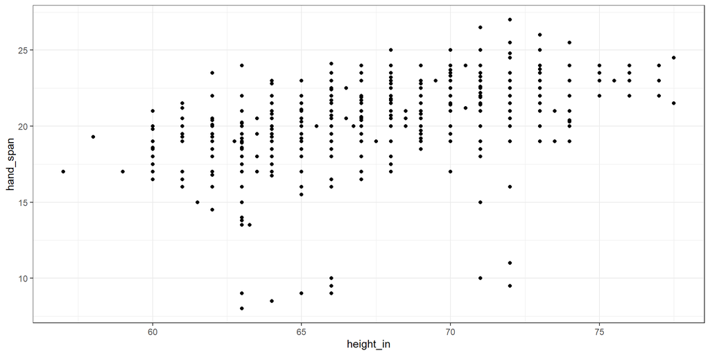

## Filtering to complete cases

Let’s require complete data on these variables…

```r
s15_q1 <- s15 |> filter(complete.cases(hand_span, height_in))

s15_q1 |> reframe(lovedist(hand_span))
```

```
# A tibble: 1 × 10
      n  miss  mean    sd   med   mad   min   q25   q75   max
  <int> <int> <dbl> <dbl> <dbl> <dbl> <dbl> <dbl> <dbl> <dbl>
1   618     0  20.3  2.52  20.5  2.22     8    19    22    27
```

```r
s15_q1 |> reframe(lovedist(height_in))
```

```
# A tibble: 1 × 10
      n  miss  mean    sd   med   mad   min   q25   q75   max
  <int> <int> <dbl> <dbl> <dbl> <dbl> <dbl> <dbl> <dbl> <dbl>
1   618     0  67.2  3.79    67  4.45    57    64    70  77.5
```

## Scatterplot of Hand Span by Height

```r
ggplot(data = s15_q1, aes(x = height_in, y = hand_span)) +
  geom_point()
```

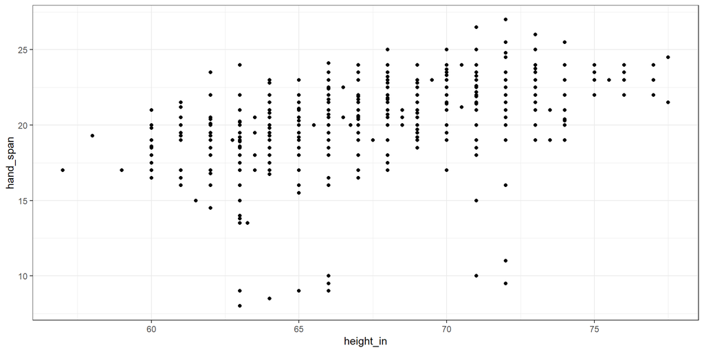

## Lots of ties - can we show that?

```r
ggplot(data = s15_q1, aes(x = height_in, y = hand_span)) +
  geom_jitter()
```

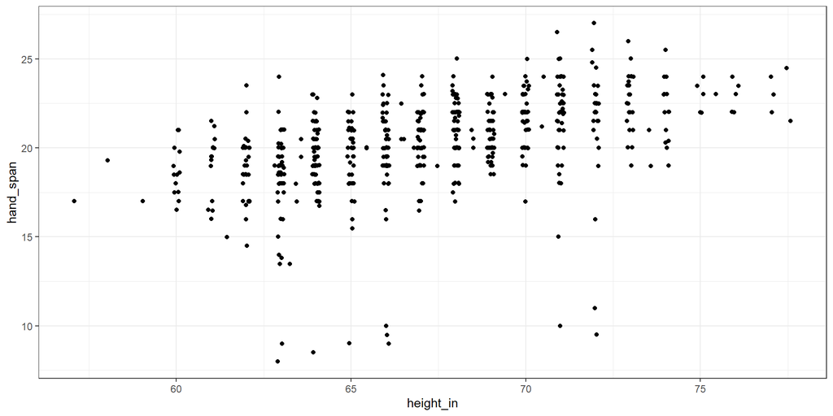

## Add a loess smooth, improve labels

```r
ggplot(data = s15_q1, aes(x = height_in, y = hand_span)) +
  geom_smooth(method = "loess", col = "blue", formula = y ~ x, se = TRUE) +
  geom_point() +
  labs(x = "Height (in)", y = "Hand Span (cm)",
       title = "Association of student hand span and height",
       subtitle = "n = 618 students in 431 between 2014 and 2026")
```

## Add a loess smooth, improve labels

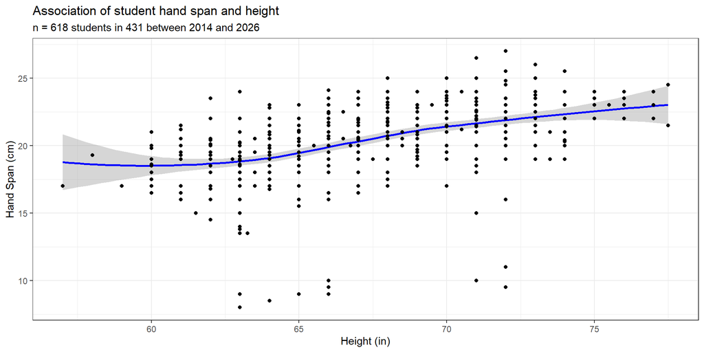

## Add a linear model, as well

```r
ggplot(data = s15_q1, aes(x = height_in, y = hand_span)) +
  geom_smooth(method = "loess", col = "blue",
              formula = y ~ x, se = FALSE) +
  geom_smooth(method = "lm", col = "red",
              formula = y ~ x, se = TRUE) +
  geom_point() +
  labs(x = "Height (in)",
       y = "Hand Span (cm)",
       title = "Association of student hand span and height",
       subtitle = "n = 618 students in 431 between 2014 and 2026")
```

## Add a linear model, as well

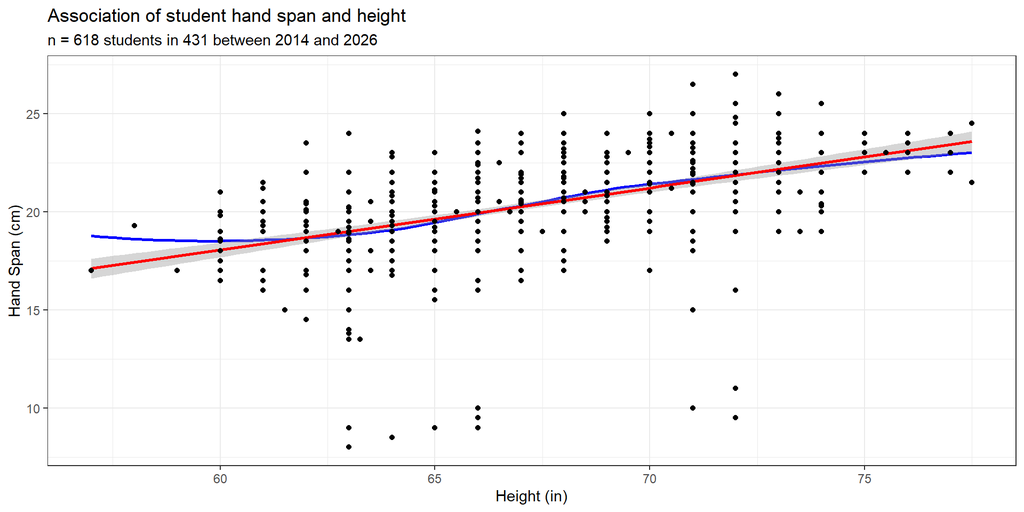

## What is the straight line fit?

```r
fit1 <- lm(hand_span ~ height_in, data = s15_q1)

model_parameters(fit1, pretty_names = FALSE, ci = 0.95)
```

```
Parameter   | Coefficient |   SE |        95% CI | t(616) |      p
------------------------------------------------------------------
(Intercept) |       -0.87 | 1.58 | [-3.98, 2.24] |  -0.55 | 0.584
height_in   |        0.32 | 0.02 | [ 0.27, 0.36] |  13.39 | < .001
```

So what is the straight line equation from `lm`?

- **hand_span** = -0.87 + 0.32 **height_in**
- How do we interpret the slope (0.32) of `height_in`?
- How do we interpret the intercept (-0.87)?

Note the 95% confidence intervals around these OLS estimates.

## Exploratory Question 2

What is the relationship between **haircut** price and **height** among the 40 students responding in 2026?

- What do we expect to see in this scatterplot? Why?

Let’s just look at 2026 data this time.

```r
s15_2026 <- s15 |> filter(year == 2026)
```

- What do the results below tell us?

```r
dim(s15_2026)
```

```
[1] 40 13
```

```r
s15_2026 |> select(haircut, height_in) |> n_miss()
```

```
[1] 0
```

## Haircut Price vs. Height in 2026

```r
ggplot(s15_2026, aes(x = height_in, y = haircut)) +
  geom_jitter() +
  geom_smooth(method = "loess", formula = y ~ x,
              se = FALSE, col = "blue") +
  geom_smooth(method = "lm", formula = y ~ x,
              se = TRUE, col = "red") +
  labs(title = "Association of haircut price and height",
       subtitle = "n = 40 students in 431 for Fall 2026 (values jittered)",
       x = "Height (in)",
       y = "Price of last haircut ($)")
```

## Haircut Price vs. Height in 2026

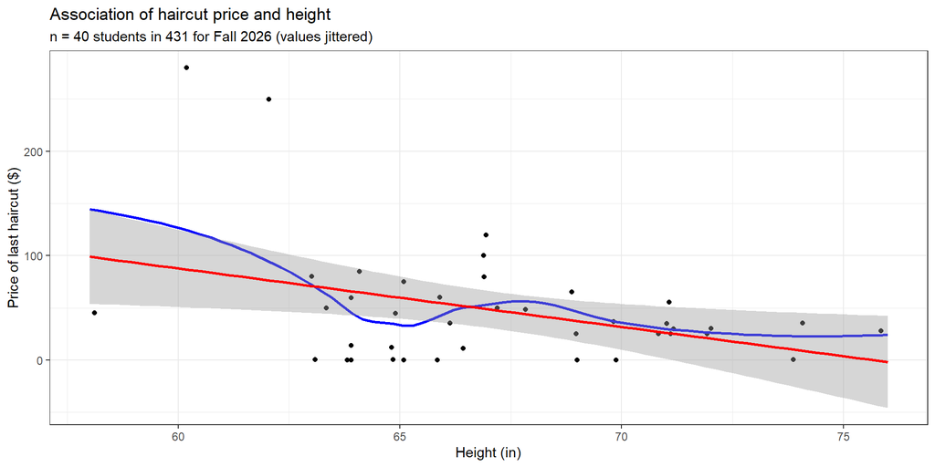

## What is the OLS model here?

```r
fit2 <- lm(haircut ~ height_in, data = s15_2026)
model_parameters(fit2, pretty_names = TRUE, ci = 0.90)
```

```
Parameter   | Coefficient |     SE |           90% CI | t(38) |     p
---------------------------------------------------------------------
(Intercept) |      423.93 | 151.20 | [169.01, 678.84] |  2.80 | 0.008
height in   |       -5.60 |   2.25 | [ -9.39,  -1.81] | -2.49 | 0.017
```

- How do we interpret the slope of `height_in`?
- How do we interpret the intercept?
- What does `pretty_names = TRUE, ci = 0.90` do?

Are we likely to see a similar result in previous years?

## Compare 2026 to 2014-2025

```r
plot1 <- ggplot(s15_2026, aes(x = height_in, y = haircut)) +
  geom_point() +
  geom_smooth(method = "loess", formula = y ~ x, se = FALSE, col = "blue") +
  geom_smooth(method = "lm", formula = y ~ x, se = TRUE, col = "red") +
  ylim(0, 300) + ## make limits of y axis 0 and 300
  labs(title = "2026: Association of haircut price and height",
       subtitle = "n = 40 students in 431 for Fall 2026",
       x = "Height (in)",  y = "Price of last haircut ($)")

s15_q2 <- s15 |> filter(complete.cases(height_in, haircut)) |>
  filter(year < 2026)  ## this contains 642 rows, it turns out

plot2 <- ggplot(s15_q2, aes(x = height_in, y = haircut)) +
  geom_point() +
  geom_smooth(method = "loess", formula = y ~ x, se = FALSE, col = "blue") +
  geom_smooth(method = "lm", formula = y ~ x, se = TRUE, col = "red") +
  ylim(0, 300) + ## make limits of y axis 0 and 300 here, too
  labs(title = "2014-2025: Association of haircut price and height",
       subtitle = "n = 642 students in 431 for 2014-2025",
       x = "Height (in)",  y = "Price of last haircut ($)")

plot1 + plot2 +                 ## "stitch" the plots together
  plot_layout(axes = "collect") ## thanks to patchwork package
```

## Compare 2026 to 2014-2025

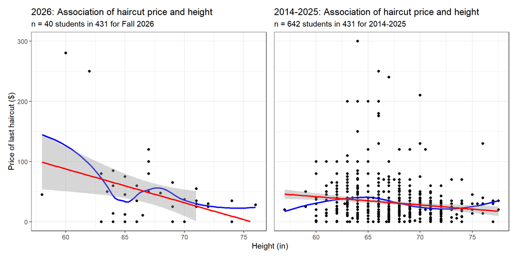

# Seems like the place for a break.

## Exploratory Question 3

Students specified their height (`height_in`) and guessed mine (`love_htcm`), since 2021.

- Did taller students guess that I was taller?
- Let’s convert the heights so each is in inches.

```r
s15_q3 <- s15 |>
  select(student, height_in, love_htcm) |>
  filter(complete.cases(height_in, love_htcm)) |>
  mutate(love_htin = round_half_up(love_htcm * 0.3937, 1)) |>
  mutate(delta = love_htin - height_in)
```

So what’s in this new tibble?

## Contents of `s15_q3` tibble

```r
s15_q3
```

```
# A tibble: 306 × 5
   student height_in love_htcm love_htin delta
   <chr>       <dbl>     <dbl>     <dbl> <dbl>
 1 202601       65         183      72    7
 2 202602       66.5       180      70.9  4.40
 3 202603       58         178      70.1 12.1
 4 202604       65         175      68.9  3.90
 5 202605       65         180      70.9  5.90
 6 202606       63         178      70.1  7.10
 7 202607       70         175      68.9 -1.10
 8 202608       63         180      70.9  7.90
 9 202609       69         180      70.9  1.90
10 202610       66         185      72.8  6.8
# ℹ 296 more rows
```

- What does `delta` mean?

## Numerical Summaries

- Student Guesses of My Height (in inches)

```r
s15_q3 |> reframe(lovedist(love_htin))
```

```
# A tibble: 1 × 10
      n  miss  mean    sd   med   mad   min   q25   q75   max
  <int> <int> <dbl> <dbl> <dbl> <dbl> <dbl> <dbl> <dbl> <dbl>
1   306     0  71.8  2.47    72  2.82  59.8  70.1    74  77.2
```

- Student Heights (in inches)

```r
s15_q3 |> reframe(lovedist(height_in))
```

```
# A tibble: 1 × 10
      n  miss  mean    sd   med   mad   min   q25   q75   max
  <int> <int> <dbl> <dbl> <dbl> <dbl> <dbl> <dbl> <dbl> <dbl>
1   306     0  67.1  3.93    67  4.45    58    64    70  77.5
```

Suppose we want to compare these means.

## Visualizing the Distributions

```r
plot3 <- ggplot(s15_q3, aes(x = love_htin)) +
  geom_histogram(binwidth = 1, fill = "tomato", col = "white") +
  labs(title = "Histogram: Guess of Dr. Love's height (inches)",
       x = "Guess of Dr. Love's height (in)", y = "# of students")

plot4 <- ggplot(s15_q3, aes(x = height_in)) +
  geom_histogram(binwidth = 1, fill = "royalblue", col = "white") +
  labs(title = "Histogram: Student height (inches)",
       x = "Student's height (in)", y = "# of students")

plot3 / plot4 + ## thanks, patchwork!
  plot_annotation(title = "306 students in Dr. Love's 431 Class, 2021-2026")
```

## Visualizing the Distributions

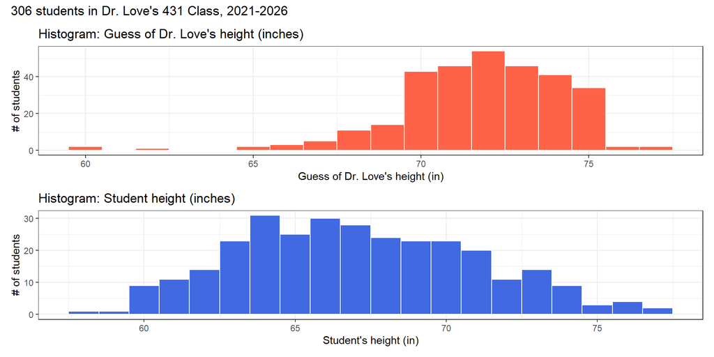

## Numerical Summaries

Each subject gives us their guess of my height, and their height.

- $\Delta$ = How much taller did I seem? (in inches)

```r
s15_q3 |> reframe(lovedist(delta))
```

```
# A tibble: 1 × 10
      n  miss  mean    sd   med   mad   min   q25   q75   max
  <int> <int> <dbl> <dbl> <dbl> <dbl> <dbl> <dbl> <dbl> <dbl>
1   306     0  4.68  4.45     5  4.45  -9.1     2     8  16.2
```

These are the “paired” differences. What do they look like?

## Histogram of $\Delta$

```r
ggplot(s15_q3, aes(x = delta)) +
  geom_histogram(binwidth = 1, fill = "aquamarine", col = "black") +
  labs(title = "How much taller did Dr. Love seem?",
       subtitle = "306 students in his 2021-2026 431 classes",
       x = "Guess of Dr. Love's height - Student's height (inches)",
       y = "# of students")
```

## Histogram of $\Delta$

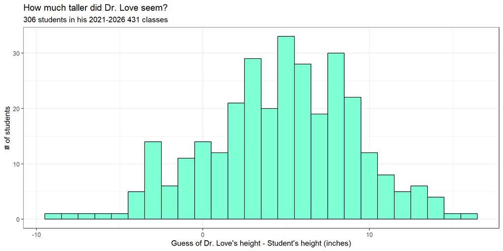

## Estimating the mean $\Delta$

Use a linear model to estimate the true mean difference between guesses of my height and actual student heights, using a **90%** confidence interval.

```r
fit3 <- lm(delta ~ 1, data = s15_q3)
model_parameters(fit3, ci = 0.90)
```

```
Parameter   | Coefficient |   SE |       90% CI | t(305) |      p
-----------------------------------------------------------------
(Intercept) |        4.68 | 0.25 | [4.26, 5.10] |  18.39 | < .001
```

- What would a **95%** confidence interval look like?

```
Parameter   | Coefficient |   SE |       95% CI | t(305) |      p
-----------------------------------------------------------------
(Intercept) |        4.68 | 0.25 | [4.18, 5.19] |  18.39 | < .001
```

## Did taller people guess I’m taller?

```r
ggplot(s15_q3, aes(x = height_in, y = love_htin)) +
  geom_jitter() +
  geom_smooth(method = "loess", formula = y ~ x, col = "blue")
```

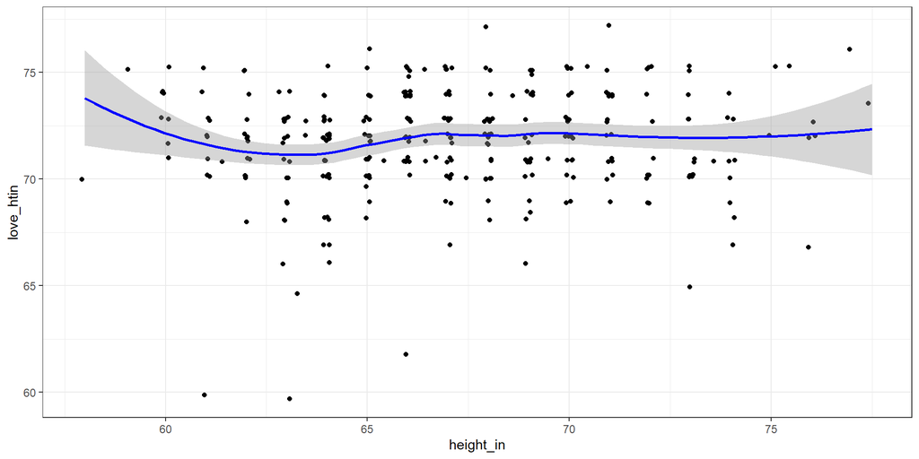

## Exploratory Question 4

Did students for whom English is their primary language have larger (or smaller) hand spans?

```r
s15_q4 <- s15 |> filter(complete.cases(english, hand_span)) |>
  select(student, english, hand_span, year)

dim(s15_q4)
```

```
[1] 613   4
```

```r
summary(s15_q4)
```

```
      student    english   hand_span          year
 Length   :613   n:131   Min.   : 8.50   Min.   :2014
 N.unique :613   y:482   1st Qu.:19.00   1st Qu.:2017
 N.blank  :  0           Median :20.50   Median :2019
 Min.nchar:  6           Mean   :20.35   Mean   :2020
 Max.nchar:  6           3rd Qu.:22.00   3rd Qu.:2023
                         Max.   :27.00   Max.   :2026
```

## Visualizing the groups

```r
ggplot(s15_q4, aes(x = hand_span, y = english)) +
  geom_violin(aes(fill = english)) +
  geom_boxplot(width = 0.4) +
  stat_summary(fun = "mean", geom = "point",
               size = 3, col = "royalblue") +
  labs(title = "Comparing hand span by preferred language",
       subtitle = "613 of Dr. Love's 431 students asked 'Is English your most comfortable language?'",
       caption = "Sample means indicated by blue dots",
       x = "Hand Span (in cm)",
       y = "Prefers English?")
```

## Visualizing the groups

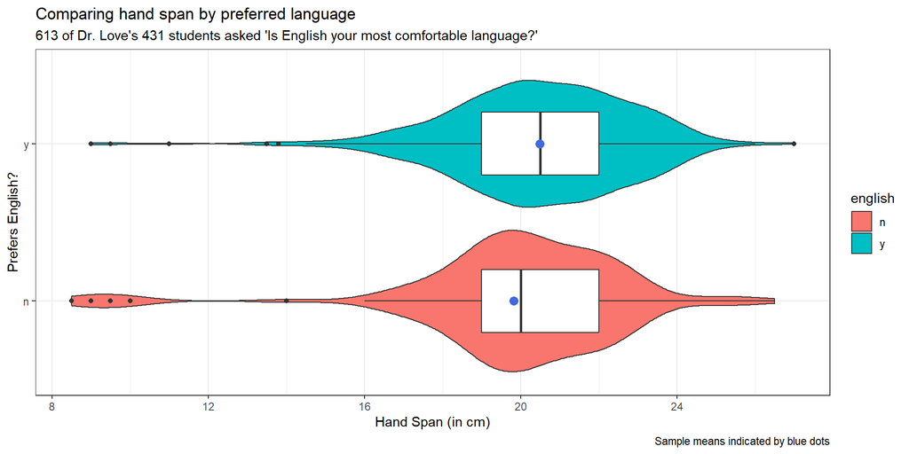

## Summarizing our Samples

- Compare the English “Yes” vs. “No” group on **hand span**.

```r
s15_q4 |> group_by(english) |>
  reframe(lovedist(hand_span))
```

```
# A tibble: 2 × 11
  english     n  miss  mean    sd   med   mad   min   q25   q75   max
  <fct>   <int> <int> <dbl> <dbl> <dbl> <dbl> <dbl> <dbl> <dbl> <dbl>
1 n         131     0  19.8  2.99  20    1.48   8.5    19    22  26.5
2 y         482     0  20.5  2.30  20.5  2.22   9      19    22  27
```

- What seems to be happening here?
- Does the difference in sample means look important?

## Build a model

Let’s use a linear model to estimate the difference in hand span between those whose primary language is English and those whose primary language is not English…

```r
fit4 <- lm(hand_span ~ english, data = s15)

model_parameters(fit4, ci = 0.90)
```

```
Parameter   | Coefficient |   SE |         90% CI | t(611) |      p
-------------------------------------------------------------------
(Intercept) |       19.82 | 0.22 | [19.47, 20.18] |  92.03 | < .001
english [y] |        0.66 | 0.24 | [ 0.26,  1.06] |   2.73 | 0.007
```

- How would you describe the point estimate here?
- What is the 90% confidence interval?

## Some Categories: Your Favorite Colors

```r
s15 |> tabyl(favcolor) |> arrange(desc(n))
```

```
      favcolor   n     percent valid_percent
          blue 251 0.360632184   0.368575624
         green 117 0.168103448   0.171806167
        purple  68 0.097701149   0.099853157
           red  62 0.089080460   0.091042584
        yellow  23 0.033045977   0.033773862
          pink  22 0.031609195   0.032305433
         black  20 0.028735632   0.029368576
        orange  18 0.025862069   0.026431718
         white  16 0.022988506   0.023494860
          <NA>  15 0.021551724            NA
          gray  11 0.015804598   0.016152717
         brown   6 0.008620690   0.008810573
    light blue   5 0.007183908   0.007342144
          navy   5 0.007183908   0.007342144
      sky blue   4 0.005747126   0.005873715
          teal   4 0.005747126   0.005873715
     turquoise   4 0.005747126   0.005873715
      lavender   3 0.004310345   0.004405286
        maroon   3 0.004310345   0.004405286
    sage green   3 0.004310345   0.004405286
          aqua   2 0.002873563   0.002936858
    aquamarine   2 0.002873563   0.002936858
     baby pink   2 0.002873563   0.002936858
      burgundy   2 0.002873563   0.002936858
     dark blue   2 0.002873563   0.002936858
    dark green   2 0.002873563   0.002936858
          none   2 0.002873563   0.002936858
    royal blue   2 0.002873563   0.002936858
        silver   2 0.002873563   0.002936858
   all of them   1 0.001436782   0.001468429
     baby blue   1 0.001436782   0.001468429
         beige   1 0.001436782   0.001468429
    blue-green   1 0.001436782   0.001468429
  burnt orange   1 0.001436782   0.001468429
    chartreuse   1 0.001436782   0.001468429
       depends   1 0.001436782   0.001468429
  forest green   1 0.001436782   0.001468429
  hunter green   1 0.001436782   0.001468429
  light purple   1 0.001436782   0.001468429
  light yellow   1 0.001436782   0.001468429
     navy blue   1 0.001436782   0.001468429
   pink-orange   1 0.001436782   0.001468429
  royal purple   1 0.001436782   0.001468429
        salmon   1 0.001436782   0.001468429
      sapphire   1 0.001436782   0.001468429
 seafoam green   1 0.001436782   0.001468429
        violet   1 0.001436782   0.001468429
```

## I collapsed these to 13 colors

```r
s15 |> tabyl(colors_13) |> arrange(desc(n)) |>
  adorn_totals() |> adorn_pct_formatting()
```

```
  colors_13   n percent valid_percent
       blue 272   39.1%         40.2%
      green 125   18.0%         18.5%
     purple  74   10.6%         10.9%
        red  67    9.6%          9.9%
       pink  25    3.6%          3.7%
     yellow  25    3.6%          3.7%
      black  20    2.9%          3.0%
     orange  20    2.9%          3.0%
       <NA>  19    2.7%             -
      white  16    2.3%          2.4%
 blue-green  13    1.9%          1.9%
       gray  11    1.6%          1.6%
      brown   7    1.0%          1.0%
     silver   2    0.3%          0.3%
      Total 696  100.0%        100.0%
```

## Glasses vs. English

This is a 2x2 table.

```r
s15 |> tabyl(glasses, english)
```

```
 glasses  n   y NA_
       n 40 119   1
       y 60 218   2
    <NA> 47 205   4
```

```r
s15 |>
  filter(complete.cases(glasses, english)) |>
  tabyl(glasses, english) |>
  adorn_totals(where = c("row", "col"))
```

```
 glasses   n   y Total
       n  40 119   159
       y  60 218   278
   Total 100 337   437
```

## Smoking Status by English

Here’s a 3x2 table.

```r
s15 |> filter(complete.cases(smoke, english)) |>
  tabyl(smoke, english) |>
  adorn_totals(where = c("row", "col")) |> knitr::kable()
```

| smoke | n | y | Total |
| --- | --- | --- | --- |
| Never | 136 | 500 | 636 |
| Quit | 5 | 33 | 38 |
| Current | 6 | 8 | 14 |
| Total | 147 | 541 | 688 |

## Finishing Up

- I’ve shown you everything you need to complete [Lab 1](https://github.com/THOMASELOVE/431-labs-2026/tree/main/lab1), due Wednesday 2026-09-09 at noon.
- `class04_survey_complete.qmd`: Quarto file with the analyses in these slides, pulling directly from [our 431-data page](https://github.com/THOMASELOVE/431-data). You can render to HTML if you like.
- As always, you have the [Quarto file for these slides](https://github.com/THOMASELOVE/431-classes-2026/tree/main/class04#todays-slides), too.

**Next week** we’ll work with new data and get into chapters 5-7 of [my book](https://thomaselove.github.io/431-book/).